# Project1

Rui Wang(rw2795)

2/4/2020

### Step 0 - Install and load all the required libraries

```r
library(stringr)
library("syuzhet")
library(tidyr)
library(dplyr)
library(purrr)
library(wordcloud)
library(memoise)
library(tidyverse)
library(tidytext)
library(plotly)
library(DT)
library(tm)
library(data.table)
library(scales)
library(wordcloud2)
library(gridExtra)
library(ngram)
library(shiny)
```

*This notebook was prepared with the following environmental settings.*

```r
print(R.version)
```

```
##                _
## platform       x86_64-apple-darwin15.6.0
## arch           x86_64
## os             darwin15.6.0
## system         x86_64, darwin15.6.0
## status
## major          3
## minor          6.1
## year           2019
## month          07
## day            05
## svn rev        76782
## language       R
## version.string R version 3.6.1 (2019-07-05)
## nickname       Action of the Toes
```

### Step 1 - Load the processed data

```r
# load processed lyrics data
# processed lyrics data was generated by "Text_Processing.Rmd"
load('../output/processed_lyrics.RData')
```

### Step 2 - Data analysis — Word Frequency

```r
dt_rock = dt_lyrics%>%
  dplyr::filter(genre == "Rock")
lyrics_rock = dt_rock %>% pull(stemmedwords) %>% paste(collapse = " ") %>%
  strsplit(" ") %>% unlist()
words_rock = tibble(words = lyrics_rock) %>%
  group_by(words) %>% count() %>%
  arrange(desc(n))

dt_hiphop = dt_lyrics %>%
  dplyr::filter(genre == "Hip-Hop")
lyrics_hiphop = dt_hiphop %>% pull(stemmedwords) %>% paste(collapse = " ") %>%
  strsplit(" ") %>% unlist()
words_hiphop = tibble(words = lyrics_hiphop) %>%
  group_by(words) %>% count() %>%
  arrange(desc(n))
```

### Step 3 - Inspect an Overall Wordcloud

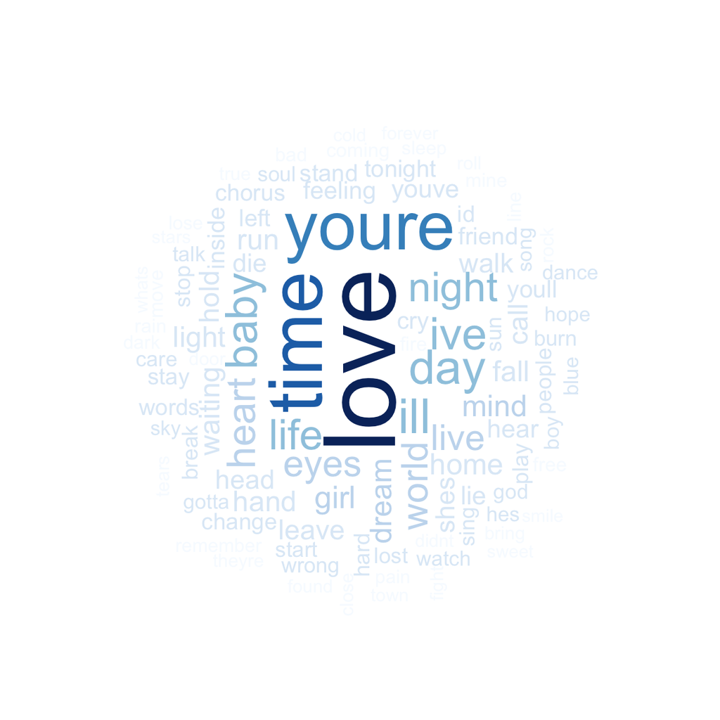

```r
wordcloud(words_rock$words, words_rock$n,
          scale=c(5,0.5),
          max.words=100,
          min.freq=1,
          random.order=FALSE,
          rot.per=0.3,
          use.r.layout=T,
          random.color=FALSE,
          colors=brewer.pal(9,"Blues"))
```

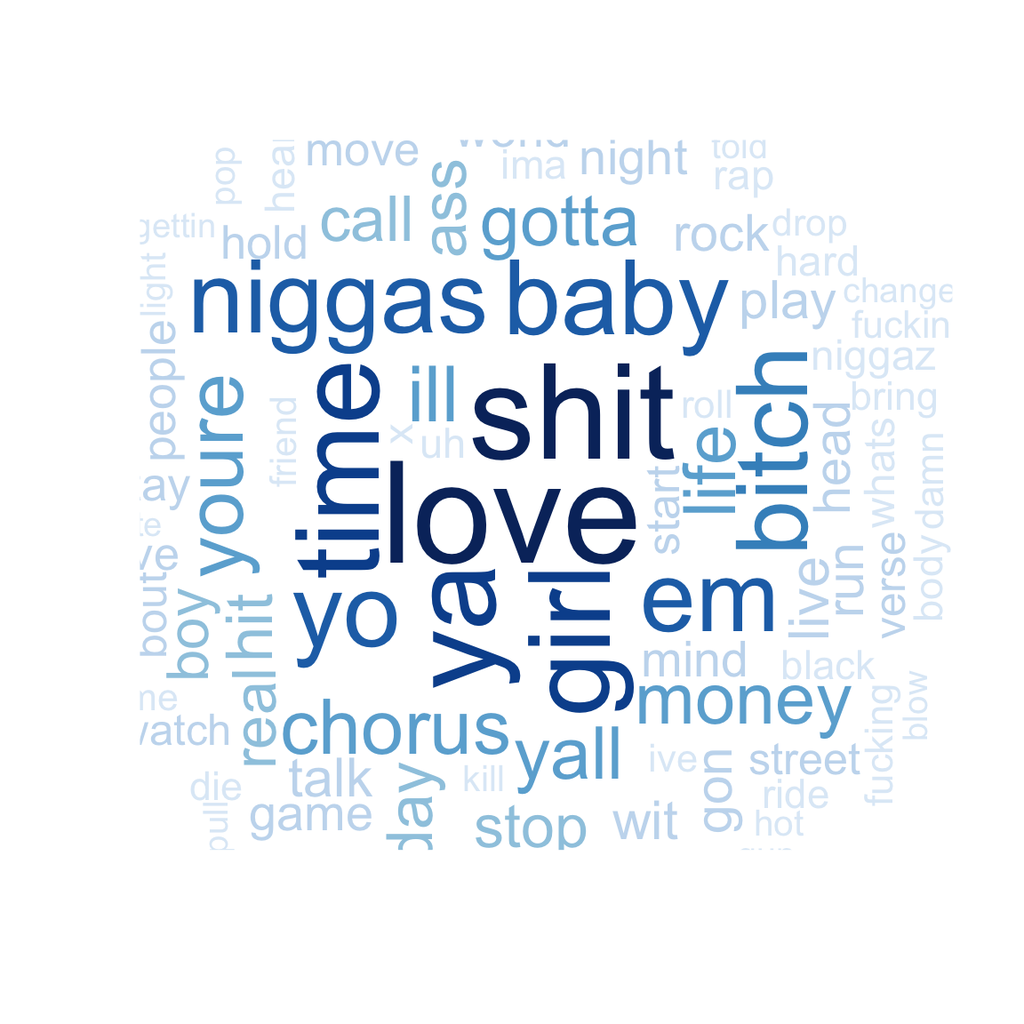

```r
wordcloud(words_hiphop$words, words_hiphop$n,
          scale=c(5,0.5),
          max.words=100,
          min.freq=1,
          random.order=FALSE,
          rot.per=0.3,
          use.r.layout=T,
          random.color=FALSE,
          colors=brewer.pal(9,"Blues"))
```

*We can see from the plots that “LOVE” is the most commonly used word in these two genres and there are many rhythmic words in hiphop lyrics, such as em, yo, ya.* *In general, the words used for Rock n roll is healthier and more gentle than Hip-Hop.*

### Step 4 - Interactive Word Cloud with Time Variation

```r
### Preparations for visualization
time_list1 <- c("1970s", "1980s", "1990s", "2000s", "2010s")
time_list2 <- c("1980s", "1990s", "2000s", "2010s")
corpus <- VCorpus(VectorSource(dt_lyrics$stemmedwords))
word_tibble <- tidy(corpus) %>%
  select(text) %>%
  mutate(id = row_number()) %>%
  unnest_tokens(word, text)

### Specify the user interface for the R Shiny app
# Define UI for app that draws a histogram ----
ui <- navbarPage(strong("Lyrics Analysis with Time Variation"),
                 tabPanel("Plots",
                          titlePanel("Rock vs. Hip-Hop"),
                          # Sidebar layout with input and output definitions ----
                          sidebarLayout(
                            # Sidebar panel for inputs ----
                            sidebarPanel(
                              sliderInput(inputId = "nwords1",
                                          label = "Number of terms in the first word cloud:",
                                          min = 5, max = 100, value = 50),
                              selectInput('decade1', 'Selected decade for the first plot:',
                                          time_list1, selected='1980s')

                            ),
                            # Main panel for displaying outputs ----
                            mainPanel(
                              wordcloud2Output(outputId = "WC1", height = "300")
                            )
                          ),
                          hr(),
                          sidebarLayout(
                            # Sidebar panel for inputs ----
                            sidebarPanel(
                              sliderInput(inputId = "nwords2",
                                          label = "Number of terms in the second word cloud:",
                                          min = 5, max = 100, value = 50),
                              selectInput('decade2', 'Selected decade for the second plot:',
                                          time_list2, selected='1980s')
                            ),
                            # Main panel for displaying outputs ----
                            mainPanel(
                              wordcloud2Output(outputId = "WC2", height = "300")
                            )
                          )
                 ),
                 tabPanel("Data",
                          DT::dataTableOutput("table"))
)

# Define server logic required for ui ----
server <- function(input, output) {
  output$WC1 <- renderWordcloud2({
    year1 = input$decade1 %>% str_sub(1, -2) %>% as.numeric()
    count(filter(word_tibble, id %in% which((dt_lyrics$genre == "Rock") & (dt_lyrics$year >= year1) & (dt_lyrics$year <= (year1 + 9)))), word, sort = TRUE) %>%
      slice(1:input$nwords1) %>%
      wordcloud2(size=0.6, rotateRatio=0.2)
  })
  output$WC2 <- renderWordcloud2({
    year2 = input$decade2 %>% str_sub(1, -2) %>% as.numeric()
    count(filter(word_tibble, id %in% which((dt_lyrics$genre == "Hip-Hop") & (dt_lyrics$year >= year2) & (dt_lyrics$year <= (year2 + 9)))), word, sort = TRUE) %>%
      slice(1:input$nwords2) %>%
      wordcloud2(size=0.6, rotateRatio=0.2)
  })
  output$table <- DT::renderDataTable({
    DT::datatable(dt_lyrics)
  })
}

### Run the R Shiny app
shinyApp(ui, server)
```

Shiny applications not supported in static R Markdown documents